# 采用贝叶斯序列分析确定样本量

2025-05-30

- 停止规则：
  - 贝叶斯因子阈值确定为10
  - 最小样本量40，最大样本量70
- 研究假设
  - 匹配任务
    - 关联类型的主效应
    - 关联类型与难度的交互作用
  - 辨别任务
    - 关联类型的主效应
    - 关联类型与难度的交互作用
  - 任务间的比较
    - 任务类型的主效应
    - 任务类型与难度的交互作用

```r
rm(list = ls())
```

下载和安装需要的R语言程序包

```r
# install.packages(c("tidyverse", "BayesFactor", "here"))
library(BayesFactor)#计算t检验和方差分析的贝叶斯因子
library(tidyverse)
library(showtext)#解决中文字体无法显示问题
library(latex2exp)#latex语法
# font_add("song",
         # "/System/Library/Fonts/Supplemental/Songti.ttc")
##从系统增加宋体字
showtext_auto()
library(here)
here()
```

```
## [1] "E:/project/Experiment/Self_Prioritization_Expt"
```

```r
options(scipen = 9)#将科学计数法改为在万后9位
set.seed(1234)
```

BayesFacotr包版本

```r
packageVersion("BayesFactor")
```

```
## [1] '0.9.12.4.7'
```

## 0.1 数据预处理

**读取目录下的原始数据**

```r
# 文件路径和文件名根据实际情况调整
# 设置目标文件夹相对路径
folder_path <- "../2_1_2_RawData/pilot_expt_all"

# 列出所有含有"pilot_expt_v4_"的csv文件
file_list <- list.files(
  path = folder_path,
  pattern = "*pilot_expt_0421_.*\\.csv$", full.names = TRUE
)

# 创建一个空列表来存储数据
df_list_1 <- list()

# 逐个读取文件并存储
for (file in file_list) {
  file_name <- tools::file_path_sans_ext(basename(file))  # 获取文件名（不带扩展名）
  df_list_1[[file_name]] <- read.csv(file)  # 将数据存储在列表中
}
#rm(file, file_list, folder_path)
```

**数据清洗**

```r
# 创建输出文件夹（如果不存在）
output_path <- "../2_1_3_CleanData/pilot_expt_all"
if (!dir.exists(output_path)) {
  dir.create(output_path, recursive = TRUE)
}

# 逐篇处理每个数据框
for (file_name in names(df_list_1)) {
  data <- df_list_1[[file_name]]

  # 提取被试信息
  participant_info <- data[data$part == "survey", "response"]
  participant_info <- gsub("[{}\"]", "", participant_info) # 去掉多余的字符
  info_list <- strsplit(participant_info, ",")[[1]]

  # 创建新的变量
  participant_data <- data.frame(
    subj_idx = file_name,
    Sex = as.character(NA),
    Age = as.numeric(NA),
    Handedness = as.character(NA),
    Color_blindness = as.character(NA),
    stringsAsFactors = FALSE
  )

  # 先按照下划线分割字符串
  split_data <- strsplit(participant_data$subj_idx, "_")
  # 提取分割后的第四个元素（数字部分在第四个位置，可根据实际调整）并转换为数值
  participant_data$subj_idx <- as.numeric(lapply(split_data, function(x) substr(x[[4]], 1, 2)))

  for (info in info_list) {
    key_value <- strsplit(info, ":")[[1]]
    key <- trimws(key_value[1])
    value <- trimws(key_value[2])
    if (key == "sex") participant_data$Sex <- value
    if (key == "age") participant_data$Age <- as.numeric(value)
    if (key == "hands") participant_data$Handedness <- value
    if (key == "color_blindness") participant_data$Color_blindness <- value
  }

  # 提取行为数据
  behavior_data <- data[
    data$part %in% c("motion_test","match_RDK","RDK"),
    c(
      "part", "rt", "response", "correct", "coherent_direction","coherence",
      "isMatch", "association", "difficulty", "dot_color_final","target_color_proportion"
    )
  ]

  # 分别提取正式试次
  official_trials <- do.call(
    rbind,
    lapply(unique(behavior_data$part), function(part) {
      part_data <- behavior_data[behavior_data$part == part, ]
      if (part == "match_RDK") {
        return(tail(part_data, 384)) # 匹配任务384次
      } else if (part == "RDK") {
        return(tail(part_data, 192)) # 辨别任务192次
      } else {
        return(NULL)
      }
    })
  )

  # 合并被试信息和行为数据
  final_data <- cbind(participant_data, official_trials)

  # 输出到新的CSV文件
  output_file <- file.path(output_path, paste0(file_name, "_Clean.csv"))
  write.csv(final_data, output_file, row.names = FALSE)
}
```

**读取清洗后的数据**

```r
# 设置目标文件夹相对路径
folder_path <- "../2_1_3_CleanData/pilot_expt_all"

# 列出所有含有"pilot_expt_"的csv文件
file_list <- list.files(
  path = folder_path,
  pattern = "*pilot_expt_0421_.*\\.csv$", full.names = TRUE
)

# 创建一个空列表来存储数据
df_list_1 <- list()

# 逐个读取文件并存储
for (file in file_list) {
  file_name <- tools::file_path_sans_ext(basename(file)) # 获取文件名（不带扩展名）
  df_list_1[[file_name]] <- read.csv(file) # 将数据存储在列表中
}

# 清除不需要的变量
rm(output_path, participant_info, info_list, participant_data, split_data,
   behavior_data, official_trials, final_data, output_file, file, file_list,
   file_name, folder_path, info, key, key_value, value)

# 把 df_list_1 传送给 data
data <- do.call(rbind, df_list_1)
```

定义函数，用来计算平均反应时、正确率和自我-他人差异(SPE)

```r
# 计算平均正确率和反应时
copmute_rt_acc <- function(data){
  data <- data %>%
  dplyr::filter(part %in% c("match_RDK","RDK")) %>%
    dplyr::group_by(subj_idx, part, difficulty, association, isMatch) %>% # 按被试与难度和关联类型分组
    dplyr::summarise(
      rt = mean(rt, na.rm = TRUE),#每个被试所有trial的平均反应时
      # rt_max = max(rt, na.rm = TRUE),#每个被试所有trial的最大反应时
      # rt_min = min(rt, na.rm = TRUE),#每个被试所有trial的最小反应时
      # sd_rt = sd(rt, na.rm = TRUE), #每个被试所有trial的反应时的方差
      # all_count = n(),#每个被试在每个条件的总trial数量
      # row_count = sum(rt >= 200 & rt <= 3000, na.rm = TRUE), #舍弃按键太快和按键太慢的反应时
      # correct_count = sum(correct == 'true' & rt >= 200 & rt <= 3000, na.rm = TRUE),
      acc = sum(correct == 'true' & rt >= 200 & rt <= 3000, na.rm = TRUE) / n(), #计算每个被试在每个条件的正确率= 正确/总数
      .groups = "drop")

    # 返回处理后的数据
    return(data)
}

# 计算自我-他人差异，即自我减去他人
compute_diff <- function(data, keepMatch=FALSE){
  # 决定分组变量
  group_vars <- if(keepMatch) {
    c("subj_idx", "part", "difficulty", "isMatch")
  } else {
    c("subj_idx", "part", "difficulty")
  }

  # 执行数据处理流程
  data_agg <- data %>%
    dplyr::filter(part %in% c("match_RDK","RDK")) %>%
    dplyr::group_by_at(group_vars) %>%  # 使用 group_by_at 接受变量名向量
    dplyr::summarise(
      rt_other = mean(rt[association == "other"], na.rm = TRUE),
      rt_self = mean(rt[association == "self"], na.rm = TRUE),
      acc_other = mean(acc[association == "other"], na.rm = TRUE),
      acc_self = mean(acc[association == "self"], na.rm = TRUE),
      .groups = "drop"
    )

  # 计算差值
  data_result <- data_agg %>%
    dplyr::mutate(
      rt_diff_os = rt_other - rt_self, # 反应时越快越好，他人-自我 > 0 为自我优势
      acc_diff_so = acc_self - acc_other # 正确率越高越好，自我-他人 > 0 为自我优势
    )

  return(data_result)
}
```

```r
# 创建输出文件夹（如果不存在）
output_path <- "../2_1_3_CleanData/pilot_expt_all"
if (!base::dir.exists(output_path)) {
  base::dir.create(output_path, recursive = TRUE)
}

data <- data %>%
  #筛出反应时在200~3000)
  dplyr::filter(rt >= 200 & rt <= 3000)

# Motion
data1 <- data %>%
  dplyr::filter(
    subj_idx %in% c( seq(1, 20))) # 被试编号 1-20 为运动组

data_motion_rt_acc <- copmute_rt_acc(data1) %>%
  dplyr::mutate(group = "motion") # %>%
  # tidyr::pivot_wider(names_from = c(part, difficulty, association),
              #values_from = c(rt, acc))

data_motion_diff <- compute_diff(data_motion_rt_acc) %>%
  #类型为character的转换为因子类型，便于后续分析
  dplyr::mutate(subj_idx = as.factor(subj_idx),
         difficulty = as.factor(difficulty))

# Color
data2 <- data %>%
  dplyr::filter(
    subj_idx %in% c( seq(21, 40))) # 后20为颜色

data_color_rt_acc <- copmute_rt_acc(data2) %>%
  dplyr::mutate(group = "color")

data_color_diff <- compute_diff(data_color_rt_acc) %>%
  #类型为character的转换为因子类型，便于后续分析
  dplyr::mutate(subj_idx = as.factor(subj_idx),
         difficulty = as.factor(difficulty))

data_color_diff_keepMatch <- compute_diff(data_color_rt_acc, TRUE) %>%
  #类型为character的转换为因子类型，便于后续分析
  dplyr::mutate(subj_idx = as.factor(subj_idx),
         difficulty = as.factor(difficulty))
```

## 0.2 数据整理

### 0.2.1 运动组-匹配任务

```r
df_motion_match <- data_motion_rt_acc %>%
  dplyr::filter(# difficulty %in% c(1, 4),
    part %in% c('match_RDK')) %>%
  dplyr::select(subj_idx, acc, rt, association, difficulty, isMatch, group) %>%
  #类型为character的转换为因子类型，便于后续分析
  dplyr::mutate(subj_idx = as.factor(subj_idx),
         association = as.factor(association),
         difficulty = as.factor(difficulty))

# 输出到新的CSV文件
  output_file <- base::file.path(output_path, "df_motion_match.csv")
  utils::write.csv(df_motion_match, output_file, row.names = FALSE)

df_motion_diff_match <- data_motion_diff %>%
  # 只选择难度为1 和 4 的
  dplyr::filter(# difficulty %in% c(1,2,3,4),
         part %in% c('match_RDK')) %>%
  dplyr::select(subj_idx, acc_diff_so, rt_diff_os, difficulty) %>%
  #类型为character的转换为因子类型，便于后续分析
  dplyr::mutate(subj_idx = as.factor(subj_idx),
         difficulty = as.factor(difficulty)) %>%
  tidyr::pivot_wider(
    names_from = difficulty,
    values_from = c(acc_diff_so, rt_diff_os),  # 同时处理acc和rt列
    names_glue = "{.value}_{difficulty}" )


# 输出到新的CSV文件
output_file <- base::file.path(output_path, "df_motion_diff_match.csv")
utils::write.csv(df_motion_diff_match, output_file, row.names = FALSE)
```

### 0.2.2 运动组-辨别任务

```r
df_motion_rdk <- data_motion_rt_acc %>%
  dplyr::filter(# difficulty %in% c(1, 4),
    part %in% c('RDK')) %>%
  dplyr::select(subj_idx, acc, rt, association, difficulty, group) %>%
  #类型为character的转换为因子类型，便于后续分析
  dplyr::mutate(subj_idx = as.factor(subj_idx),
         association = as.factor(association),
         difficulty = as.factor(difficulty))

# 输出到新的CSV文件
output_file <- base::file.path(output_path, "df_motion_rdk.csv")
utils::write.csv(df_motion_rdk, output_file, row.names = FALSE)

df_motion_diff_rdk <- data_motion_diff %>%
  # 只选择难度为1 和 4 的
  dplyr::filter(difficulty %in% c(1, 2, 3, 4), part %in% c('RDK')) %>%
  dplyr::select(subj_idx, acc_diff_so, rt_diff_os, difficulty) %>%
  #类型为character的转换为因子类型，便于后续分析
  dplyr::mutate(subj_idx = as.factor(subj_idx),
         difficulty = as.factor(difficulty)) %>%
  tidyr::pivot_wider(
    names_from = difficulty,
    values_from = c(acc_diff_so, rt_diff_os),  # 同时处理acc和rt列
    names_glue = "{.value}_{difficulty}" )


# 输出到新的CSV文件
output_file <- base::file.path(output_path, "df_motion_diff_rdk.csv")
utils::write.csv(df_motion_diff_rdk, output_file, row.names = FALSE)
```

### 0.2.3 颜色组-匹配任务

```r
df_color_match <- data_color_rt_acc %>%
  dplyr::filter(# difficulty %in% c(1, 4),
    part %in% c('match_RDK')) %>%
  dplyr::select(subj_idx, acc, rt, association, difficulty, isMatch, group) %>%
  #类型为character的转换为因子类型，便于后续分析
  dplyr::mutate(subj_idx = as.factor(subj_idx),
         association = as.factor(association),
         difficulty = as.factor(difficulty))

df_color_match_matchTrial <- data_color_rt_acc %>%
  dplyr::filter(isMatch %in% c('match'),
    part %in% c('match_RDK')) %>%
  dplyr::select(subj_idx, acc, rt, association, difficulty, isMatch, group) %>%
  #类型为character的转换为因子类型，便于后续分析
  dplyr::mutate(subj_idx = as.factor(subj_idx),
         association = as.factor(association),
         difficulty = as.factor(difficulty))

df_color_match_nonmatchTrial <- data_color_rt_acc %>%
  dplyr::filter(isMatch %in% c('mismatch'),
    part %in% c('match_RDK')) %>%
  dplyr::select(subj_idx, acc, rt, association, difficulty, isMatch, group) %>%
  #类型为character的转换为因子类型，便于后续分析
  dplyr::mutate(subj_idx = as.factor(subj_idx),
         association = as.factor(association),
         difficulty = as.factor(difficulty))

# 输出到新的CSV文件
output_file <- base::file.path(output_path, "df_color_match.csv")
utils::write.csv(df_color_match, output_file, row.names = FALSE)

df_color_diff_match <- data_color_diff %>%
  # 只选择难度为1 和 4 的
  dplyr::filter(difficulty %in% c(1, 2, 3, 4),
         part %in% c('match_RDK')) %>%
  dplyr::select(subj_idx, acc_diff_so, rt_diff_os, difficulty) %>%
  #类型为character的转换为因子类型，便于后续分析
  dplyr::mutate(subj_idx = as.factor(subj_idx),
         difficulty = as.factor(difficulty)) %>%
  tidyr::pivot_wider(
    names_from = difficulty,
    values_from = c(acc_diff_so, rt_diff_os),  # 同时处理acc和rt列
    names_glue = "{.value}_{difficulty}" )

df_color_diff_match_matchTrial <- data_color_diff_keepMatch %>%
  # 选出匹配试次
  dplyr::filter(isMatch %in% c('match'),
         part %in% c('match_RDK')) %>%
  dplyr::select(subj_idx, acc_diff_so, rt_diff_os, difficulty) %>%
  #类型为character的转换为因子类型，便于后续分析
  dplyr::mutate(subj_idx = as.factor(subj_idx),
         difficulty = as.factor(difficulty)) %>%
  tidyr::pivot_wider(
    names_from = difficulty,
    values_from = c(acc_diff_so, rt_diff_os),  # 同时处理acc和rt列
    names_glue = "{.value}_{difficulty}" )

df_color_diff_match_nonmatchTrial <- data_color_diff_keepMatch %>%
  # 选出不匹配试次
  dplyr::filter(isMatch %in% c('mismatch'),
         part %in% c('match_RDK')) %>%
  dplyr::select(subj_idx, acc_diff_so, rt_diff_os, difficulty) %>%
  #类型为character的转换为因子类型，便于后续分析
  dplyr::mutate(subj_idx = as.factor(subj_idx),
         difficulty = as.factor(difficulty)) %>%
  tidyr::pivot_wider(
    names_from = difficulty,
    values_from = c(acc_diff_so, rt_diff_os),  # 同时处理acc和rt列
    names_glue = "{.value}_{difficulty}" )


# 输出到新的CSV文件
output_file <- base::file.path(output_path, "df_color_diff_match.csv")
utils::write.csv(df_color_diff_match, output_file, row.names = FALSE)
```

### 0.2.4 颜色组-辨别任务

```r
df_color_rdk <- data_color_rt_acc %>%
  dplyr::filter(# difficulty %in% c(1, 4),
    part %in% c('RDK')) %>%
  dplyr::select(subj_idx, acc, rt, association, difficulty, group) %>%
  #类型为character的转换为因子类型，便于后续分析
  dplyr::mutate(subj_idx = as.factor(subj_idx),
         association = as.factor(association),
         difficulty = as.factor(difficulty))

# 输出到新的CSV文件
output_file <- base::file.path(output_path, "df_color_rdk.csv")
utils::write.csv(df_color_rdk, output_file, row.names = FALSE)

df_color_diff_rdk <- data_color_diff %>%
  # 只选择难度为1 和 4 的
  dplyr::filter(difficulty %in% c(1, 2, 3, 4), part %in% c('RDK')) %>%
  dplyr::select(subj_idx, acc_diff_so, rt_diff_os, difficulty) %>%
  #类型为character的转换为因子类型，便于后续分析
  dplyr::mutate(subj_idx = as.factor(subj_idx),
         difficulty = as.factor(difficulty)) %>%
  tidyr::pivot_wider(
    names_from = difficulty,
    values_from = c(acc_diff_so, rt_diff_os),  # 同时处理acc和rt列
    names_glue = "{.value}_{difficulty}" )


# 输出到新的CSV文件
output_file <- base::file.path(output_path, "df_color_diff_rdk.csv")
utils::write.csv(df_color_diff_rdk, output_file, row.names = FALSE)
```

## 0.3 BF 值计算

**定义函数,用来计算所关注效应的 BF 值与绘图**

```r
bf_aov <- function(data, dv='acc', v='association') {
  set.seed(1234)

  subj_num <- base::unique(data$subj_idx) # 每个被试的编号
  n <- base::length(unique(data$subj_idx)) # 获取被试数量

  bfs_int <- base::rep(1, length(subj_num))
  bfs_a <- base::rep(1, length(subj_num))
  bfs_diff <- base::rep(1, length(subj_num))

  for (i in base::seq_along(subj_num)) {
    if (i == 1) {
      next # 由于一个被试不能正确计算贝叶斯因子，所以当i等于1时，跳过
    }
    # 使用dv参数构建公式
    dv_formula <- stats::as.formula(base::paste(dv, "~ 1 + subj_idx + difficulty:subj_idx +", v, ":subj_idx"))

    # 零模型
    null_model <- BayesFactor::lmBF(
      dv_formula,
      data = data,
      whichRandom = "subj_idx",
      rscaleFixed = 0.5,
      rscaleRandom = 1,
      iteration = 10000
    )

    # 仅包含 difficulty 主效应
    model_difficulty <- BayesFactor::lmBF(
      update(dv_formula, paste(". ~ . + difficulty")),
      data = data,
      whichRandom = "subj_idx",
      rscaleFixed = 0.5,
      rscaleRandom = 1,
      iteration = 10000
    )

    # 仅包含 v 主效应
    model_association <- BayesFactor::lmBF(
      update(dv_formula, paste(". ~ . +", v)),
      data = data,
      whichRandom = "subj_idx",
      rscaleFixed = 0.5,
      rscaleRandom = 1,
      iteration = 10000
    )

    # 包含两个主效应
    model_main <- BayesFactor::lmBF(
      update(dv_formula, paste(". ~ . + difficulty +", v)),
      data = data,
      whichRandom = "subj_idx",
      rscaleFixed = 0.5,
      rscaleRandom = 1,
      iteration = 10000
    )

    # 包含主效应和交互作用
    model_int <- BayesFactor::lmBF(
      update(dv_formula, paste(". ~ . + difficulty *", v)),
      data = data,
      whichRandom = "subj_idx",
      rscaleFixed = 0.5,
      rscaleRandom = 1,
      iteration = 10000
    )

    bfs_int[i] <- model_int / model_main
    bfs_a[i] <- model_main / model_difficulty
    bfs_diff[i] <- model_main / model_association
  }

  aov_output <- tibble::tibble(
    bfs_a = bfs_a,
    bfs_diff = bfs_diff,
    bfs_int = bfs_int
  )

  print(aov_output)
  return(aov_output)
}
```

```r
# 定义函数，用来对交互效应进行进一步检验
# 计算 bf 值，用贝叶斯配对样本t检验进一步检验交互作用
bf_pairwise_tests <- function(data, prefix = "acc_diff_so_") {

  set.seed(1234)
  pairs <- utils::combn(1:4, 2, simplify = FALSE)
  subj_num <- base::unique(data$subj_idx)

  # 创建嵌套列表存储所有结果
  all_results <- list()
  for (i in base::seq_along(subj_num)) { # i遍历subj_num
  if (i == 1) {
    next
  }
    current_subj <- base::unique(data$subj_idx)[1:i]
    df_sub <- data[data$subj_idx %in% current_subj, ]

    # 存储当前迭代的结果
    iter_results <- list()

    for (pair in pairs) {
      col1 <- base::paste0(prefix, pair[1])
      col2 <- base::paste0(prefix, pair[2])
      x <- df_sub[[col1]]
      y <- df_sub[[col2]]

      # 进行贝叶斯检验
      bf <- BayesFactor::ttestBF(x, y, paired = TRUE, nullInterval = c(0, Inf))

      iter_results[[base::paste(pair[1], "vs", pair[2])]] <- list(
        BF = exp(bf@bayesFactor$bf[1]),
        Direction = mean(x - y)
      )
    }
    all_results[[base::paste0("", i)]] <- iter_results
  }
  return(all_results)
}
```

```r
# 绘图函数，用来绘制主效应的图
plot_aov <- function(aov_output, dv, condition) {

  data_plot <- aov_output %>%
  dplyr::mutate(n = 1:nrow(.)) %>%
  tidyr::pivot_longer(bfs_a:bfs_int, names_to = "Effect",
                      values_to = "Bayes_Factor") %>%
  dplyr::mutate(dplyr::across(where(is.double),
                              ~round(.x, digits = 2)))

  plot_obj <- data_plot %>%
    dplyr::filter(Effect == dv ) %>%
    ggplot2::ggplot(aes(x = n, y = Bayes_Factor)) +
    geom_point(size = 3) +
    geom_line() +
    geom_hline(aes(yintercept = log(1)), linetype = "dashed") +
    geom_hline(aes(yintercept = log(10)), linetype = "dashed") +
    labs(y = TeX("$\\BF_{10}$")) +
    ggtitle(paste(condition)) +
    theme(
      panel.background = element_blank(),
      plot.margin = unit(c(1, 1, 1, 1), "cm"),
      plot.background = element_rect(fill = "white", color = NA),
      plot.title = element_text(size = 22,
                                # family = "song",
                                face = "bold",
                                hjust = 0.5,
                                margin = margin(b = 15)),
      axis.line = element_line(color = "black", linewidth = .5),
      axis.title = element_text(size = 18, color = "black",
                                face = "bold"),
      axis.text = element_text(size = 15, color = "black"),
      axis.text.x = element_text(margin = margin(t = 10)),
      axis.title.y = element_text(margin = margin(r = 10)),
      axis.ticks = element_line(size = .5),
      panel.grid = element_blank(),
      legend.position.inside = c(0.20, 0.8),
      legend.background = element_rect(color = "black"),
      legend.text = element_text(size = 15),
      legend.margin = margin(t = 5, l = 5, r = 5, b = 5),
      legend.key = element_rect(color = NA, fill = NA)
    )

  return(plot_obj)
}
```

```r
# 绘图函数，用来绘制t检验的图
plot_ttest <- function(data, dv, condition) {

  plot_obj <- data %>%
    dplyr::filter(Effect == dv ) %>%
    ggplot2::ggplot(aes(x = subj_idx, y = BFs, group = 1)) +
    geom_point(size = 3) +
    geom_line() +
    geom_hline(aes(yintercept = log(1)), linetype = "dashed") +
    geom_hline(aes(yintercept = log(10)), linetype = "dashed") +
    labs(y = TeX("$\\BF_{10}$"), x = 'n') +
    ggtitle(paste(condition)) +
    theme(
      panel.background = element_blank(),
      plot.margin = unit(c(1, 1, 1, 1), "cm"),
      plot.background = element_rect(fill = "white", color = NA),
      plot.title = element_text(size = 22,
                                # family = "song",
                                face = "bold",
                                hjust = 0.5,
                                margin = margin(b = 15)),
      axis.line = element_line(color = "black", linewidth = .5),
      axis.title = element_text(size = 18, color = "black",
                                face = "bold"),
      axis.text = element_text(size = 15, color = "black"),
      axis.text.x = element_text(margin = margin(t = 10)),
      axis.title.y = element_text(margin = margin(r = 10)),
      axis.ticks = element_line(size = .5),
      panel.grid = element_blank(),
      legend.position.inside = c(0.20, 0.8),
      legend.background = element_rect(color = "black"),
      legend.text = element_text(size = 15),
      legend.margin = margin(t = 5, l = 5, r = 5, b = 5),
      legend.key = element_rect(color = NA, fill = NA)
    )

  return(plot_obj)
}
```

### 0.3.1 运动组

**先检查是否存在匹配类型与关联类型的交互作用**

ACC

```r
set.seed(1234)

# 零模型
null_model <- BayesFactor::lmBF(
  acc ~ 1 + subj_idx + isMatch:subj_idx + association:subj_idx,
  data = df_motion_match,
  whichRandom = "subj_idx",
  rscaleFixed = 0.5,
  rscaleRandom = 1,
  iteration = 10000)
# 仅包含 match 主效应
model_match <- BayesFactor::lmBF(
  acc ~ isMatch + subj_idx + isMatch:subj_idx + association:subj_idx,
  data = df_motion_match,
  whichRandom = "subj_idx",
  rscaleFixed = 0.5,
  rscaleRandom = 1,
  iteration = 10000)
# 仅包含 association 主效应
model_association <- BayesFactor::lmBF(
  acc ~ association + subj_idx + isMatch:subj_idx + association:subj_idx,
  data = df_motion_match,
  whichRandom = "subj_idx",
  rscaleFixed = 0.5,
  rscaleRandom = 1,
  iteration = 10000)
# 包含两个主效应（match + association）
model_main <- BayesFactor::lmBF(
  acc ~ isMatch + association + subj_idx + isMatch:subj_idx + association:subj_idx,
  data = df_motion_match,
  whichRandom = "subj_idx",
  rscaleFixed = 0.5,
  rscaleRandom = 1,
  iteration = 10000)
# 包含主效应和交互作用（isMatch * association）
model_int <- BayesFactor::lmBF(
  acc ~ isMatch * association + subj_idx + isMatch:subj_idx + association:subj_idx,
  data = df_motion_match,
  whichRandom = "subj_idx",
  rscaleFixed = 0.5,
  rscaleRandom = 1,
  iteration = 10000)
# 计算BF值
bf_int <- model_int / model_main
bf_ass <- model_main / model_match
bf_match <- model_main / model_association

print(bf_int)
```

```
## Bayes factor analysis
## --------------
## [1] isMatch * association + subj_idx + isMatch:subj_idx + association:subj_idx : 0.2133986 ±2.52%
##
## Against denominator:
##   acc ~ isMatch + association + subj_idx + isMatch:subj_idx + association:subj_idx
## ---
## Bayes factor type: BFlinearModel, JZS
```

```r
print(bf_ass)
```

```
## Bayes factor analysis
## --------------
## [1] isMatch + association + subj_idx + isMatch:subj_idx + association:subj_idx : 16.47387 ±1.68%
##
## Against denominator:
##   acc ~ isMatch + subj_idx + isMatch:subj_idx + association:subj_idx
## ---
## Bayes factor type: BFlinearModel, JZS
```

```r
print(bf_match)
```

```
## Bayes factor analysis
## --------------
## [1] isMatch + association + subj_idx + isMatch:subj_idx + association:subj_idx : 0.2479341 ±1.59%
##
## Against denominator:
##   acc ~ association + subj_idx + isMatch:subj_idx + association:subj_idx
## ---
## Bayes factor type: BFlinearModel, JZS
```

RT

```r
set.seed(1234)

# 零模型
null_model <- BayesFactor::lmBF(
  rt ~ 1 + subj_idx + isMatch:subj_idx + association:subj_idx,
  data = df_motion_match,
  whichRandom = "subj_idx",
  rscaleFixed = 0.5,
  rscaleRandom = 1,
  iteration = 10000)
# 仅包含 match 主效应
model_match <- BayesFactor::lmBF(
  rt ~ isMatch + subj_idx + isMatch:subj_idx + association:subj_idx,
  data = df_motion_match,
  whichRandom = "subj_idx",
  rscaleFixed = 0.5,
  rscaleRandom = 1,
  iteration = 10000)
# 仅包含 association 主效应
model_association <- BayesFactor::lmBF(
  rt ~ association + subj_idx + isMatch:subj_idx + association:subj_idx,
  data = df_motion_match,
  whichRandom = "subj_idx",
  rscaleFixed = 0.5,
  rscaleRandom = 1,
  iteration = 10000)
# 包含两个主效应（match + association）
model_main <- BayesFactor::lmBF(
  rt ~ isMatch + association + subj_idx + isMatch:subj_idx + association:subj_idx,
  data = df_motion_match,
  whichRandom = "subj_idx",
  rscaleFixed = 0.5,
  rscaleRandom = 1,
  iteration = 10000)
# 包含主效应和交互作用（isMatch * association）
model_int <- BayesFactor::lmBF(
  rt ~ isMatch * association + subj_idx + isMatch:subj_idx + association:subj_idx,
  data = df_motion_match,
  whichRandom = "subj_idx",
  rscaleFixed = 0.5,
  rscaleRandom = 1,
  iteration = 10000)
# 计算BF值
bf_int <- model_int / model_main
bf_ass <- model_main / model_match
bf_match <- model_main / model_association

print(bf_int)
```

```
## Bayes factor analysis
## --------------
## [1] isMatch * association + subj_idx + isMatch:subj_idx + association:subj_idx : 0.2226262 ±2.54%
##
## Against denominator:
##   rt ~ isMatch + association + subj_idx + isMatch:subj_idx + association:subj_idx
## ---
## Bayes factor type: BFlinearModel, JZS
```

```r
print(bf_ass)
```

```
## Bayes factor analysis
## --------------
## [1] isMatch + association + subj_idx + isMatch:subj_idx + association:subj_idx : 1.266498 ±1.73%
##
## Against denominator:
##   rt ~ isMatch + subj_idx + isMatch:subj_idx + association:subj_idx
## ---
## Bayes factor type: BFlinearModel, JZS
```

```r
print(bf_match)
```

```
## Bayes factor analysis
## --------------
## [1] isMatch + association + subj_idx + isMatch:subj_idx + association:subj_idx : 0.5255051 ±1.63%
##
## Against denominator:
##   rt ~ association + subj_idx + isMatch:subj_idx + association:subj_idx
## ---
## Bayes factor type: BFlinearModel, JZS
```

#### 0.3.1.1 匹配任务

##### 0.3.1.1.1 关联类型主效应

###### 0.3.1.1.1.1 ACC

```r
bfs_association_mm_acc <- bf_aov(df_motion_match, 'acc', 'association')
```

[output not shown]

[output cut: 15 more lines]

[output not shown]

```
## # A tibble: 15 × 3
##    bfs_a  bfs_diff bfs_int
##    <dbl>     <dbl>   <dbl>
##  1   1          1     1
##  2  25.2 24593824.    2.22
##  3  25.7 25281103.    2.14
##  4  24.1 24855261.    2.23
##  5  25.5 24080916.    2.23
##  6  24.8 24189364.    2.20
##  7  26.6 26009846.    2.10
##  8  25.7 24707701.    2.19
##  9  26.0 25189199.    2.14
## 10  25.8 25343984.    2.28
## 11  25.7 24842367.    2.18
## 12  25.9 25328496.    2.18
## 13  25.1 24662184.    2.19
## 14  25.8 24781544.    2.20
## 15  25.8 25153865.    2.12
```

```r
bfs_association_mm_acc
```

```
## # A tibble: 15 × 3
##    bfs_a  bfs_diff bfs_int
##    <dbl>     <dbl>   <dbl>
##  1   1          1     1
##  2  25.2 24593824.    2.22
##  3  25.7 25281103.    2.14
##  4  24.1 24855261.    2.23
##  5  25.5 24080916.    2.23
##  6  24.8 24189364.    2.20
##  7  26.6 26009846.    2.10
##  8  25.7 24707701.    2.19
##  9  26.0 25189199.    2.14
## 10  25.8 25343984.    2.28
## 11  25.7 24842367.    2.18
## 12  25.9 25328496.    2.18
## 13  25.1 24662184.    2.19
## 14  25.8 24781544.    2.20
## 15  25.8 25153865.    2.12
```

**可视化**

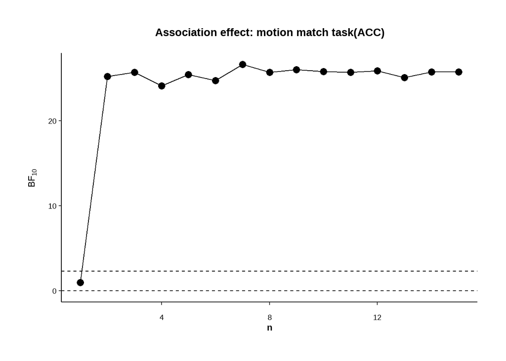

```r
plot_bfs_association <- plot_aov(bfs_association_mm_acc, 'bfs_a', 'Association effect: motion match task(ACC)')
plot_bfs_association
```

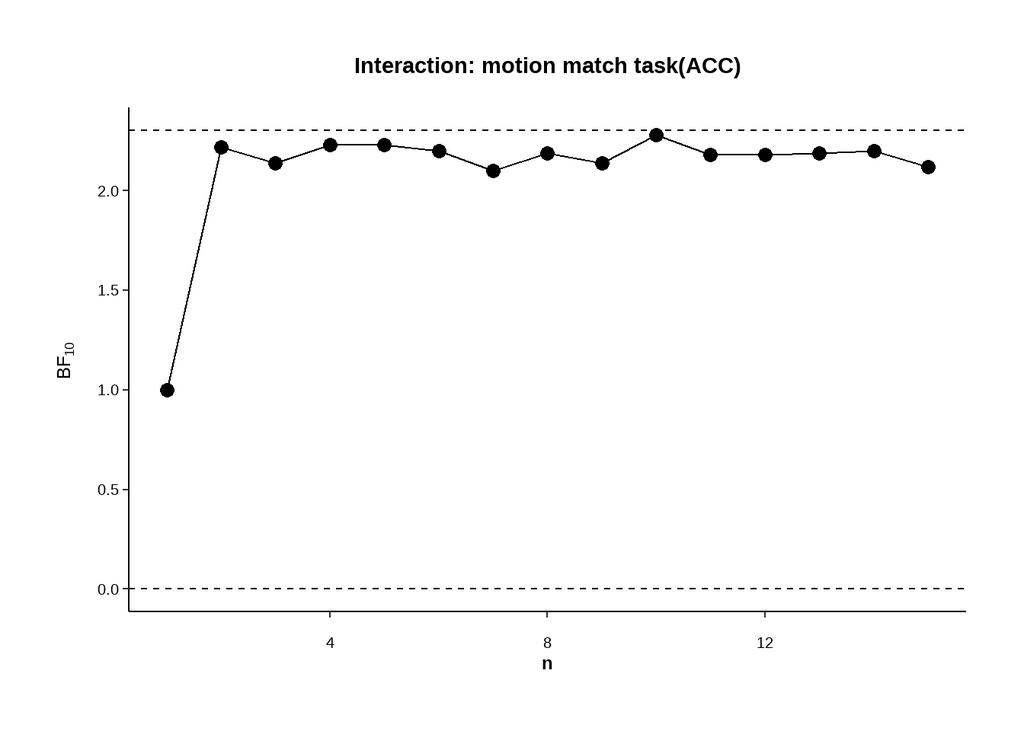

```r
plot_bfs_int <- plot_aov(bfs_association_mm_acc, 'bfs_int', 'Interaction: motion match task(ACC)')
plot_bfs_int
```

###### 0.3.1.1.1.2 RT

```r
bfs_association_mm_rt <- bf_aov(df_motion_match, 'rt')
```

[output not shown]

[output cut: 15 more lines]

[output not shown]

```
## # A tibble: 15 × 3
##    bfs_a bfs_diff bfs_int
##    <dbl>    <dbl>   <dbl>
##  1  1          1    1
##  2  1.69  672482.   0.129
##  3  1.73  692074.   0.124
##  4  1.62  681757.   0.129
##  5  1.70  657069.   0.129
##  6  1.67  663038.   0.127
##  7  1.79  714304.   0.121
##  8  1.73  679630.   0.127
##  9  1.75  690844.   0.123
## 10  1.73  694561.   0.133
## 11  1.73  681399.   0.126
## 12  1.75  697114.   0.126
## 13  1.69  678278.   0.126
## 14  1.73  680415.   0.126
## 15  1.73  690200.   0.123
```

```r
bfs_association_mm_rt
```

```
## # A tibble: 15 × 3
##    bfs_a bfs_diff bfs_int
##    <dbl>    <dbl>   <dbl>
##  1  1          1    1
##  2  1.69  672482.   0.129
##  3  1.73  692074.   0.124
##  4  1.62  681757.   0.129
##  5  1.70  657069.   0.129
##  6  1.67  663038.   0.127
##  7  1.79  714304.   0.121
##  8  1.73  679630.   0.127
##  9  1.75  690844.   0.123
## 10  1.73  694561.   0.133
## 11  1.73  681399.   0.126
## 12  1.75  697114.   0.126
## 13  1.69  678278.   0.126
## 14  1.73  680415.   0.126
## 15  1.73  690200.   0.123
```

**可视化**

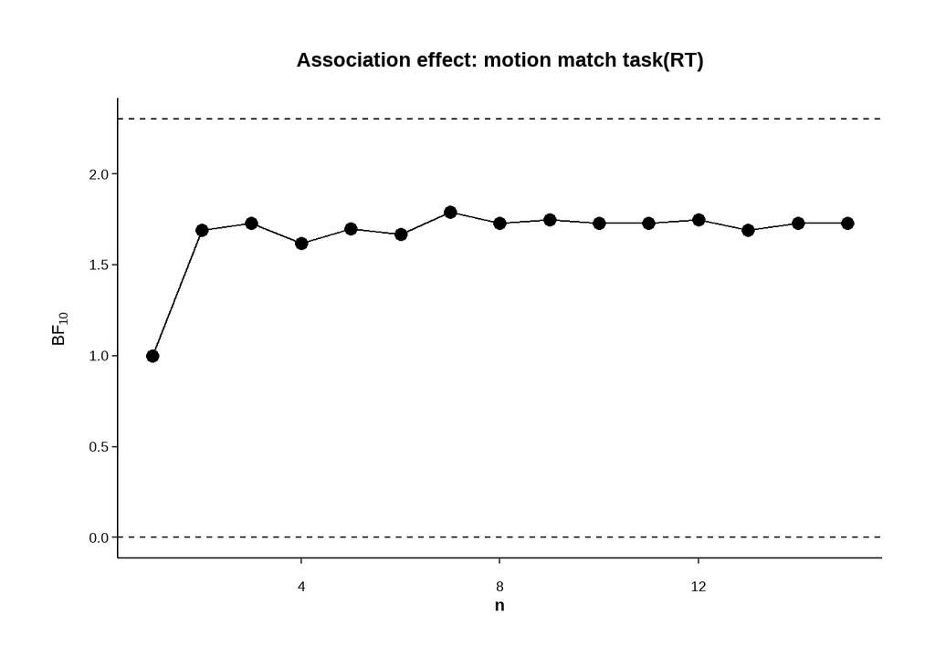

```r
plot_bfs_association <- plot_aov(bfs_association_mm_rt, 'bfs_a', 'Association effect: motion match task(RT)')
plot_bfs_association
```

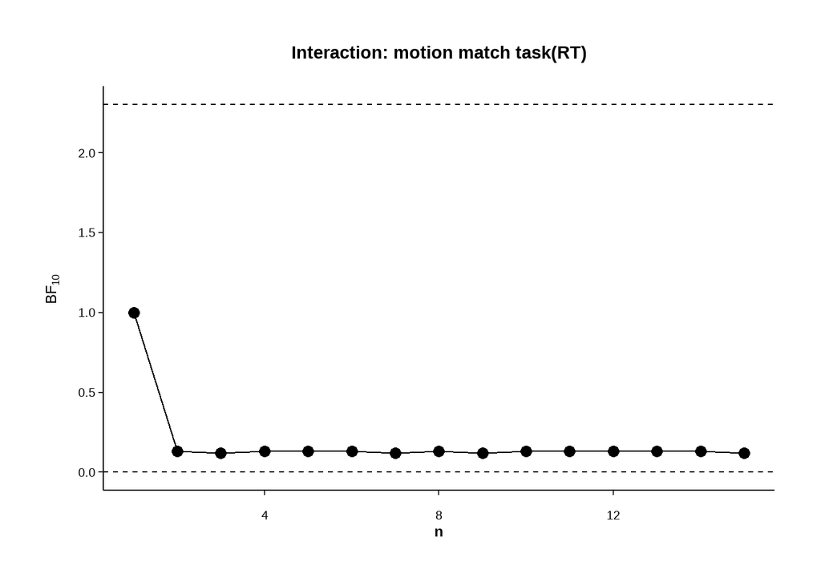

```r
plot_bfs_int <- plot_aov(bfs_association_mm_rt, 'bfs_int', 'Interaction: motion match task(RT)')
plot_bfs_int
```

##### 0.3.1.1.2 关联类型和难度的交互效应

###### 0.3.1.1.2.1 ACC

```r
# 调用函数进行不同条件的两两比较
bfs_int_diff_mm_acc <- bf_pairwise_tests(df_motion_diff_match, "acc_diff_so_")

# 提取BF值到数据框
bfs_int_diff_mm_acc <- do.call(rbind, lapply(names(bfs_int_diff_mm_acc), function(iter){
  do.call(rbind, lapply(names(bfs_int_diff_mm_acc[[iter]]), function(comparison){
    data.frame(
      subj_idx = iter,
      Effect = comparison,
      BFs = bfs_int_diff_mm_acc[[iter]][[comparison]]$BF,
      Direction = bfs_int_diff_mm_acc[[iter]][[comparison]]$Direction
    )
  }))
})) %>%
  mutate(subj_idx = as.numeric(subj_idx))

bfs_int_diff_mm_acc
```

```
##    subj_idx Effect        BFs    Direction
## 1         2 1 vs 2  0.6950396  0.011193064
## 2         2 1 vs 3  0.9714791  0.018404150
## 3         2 1 vs 4  0.4229735 -0.027697393
## 4         2 2 vs 3  0.5779196  0.007211086
## 5         2 2 vs 4  0.4226893 -0.038890457
## 6         2 3 vs 4  0.3607080 -0.046101543
## 7         3 1 vs 2  0.3981593 -0.006426846
## 8         3 1 vs 3  0.4615555 -0.000411726
## 9         3 1 vs 4  0.3343785 -0.027942468
## 10        3 2 vs 3  0.5372080  0.006015120
## 11        3 2 vs 4  0.3819383 -0.021515622
## 12        3 3 vs 4  0.3193762 -0.027530742
## 13        4 1 vs 2  0.8227463  0.043187112
## 14        4 1 vs 3  0.8703411  0.032526350
```

[output cut: 70 more lines]

**可视化**

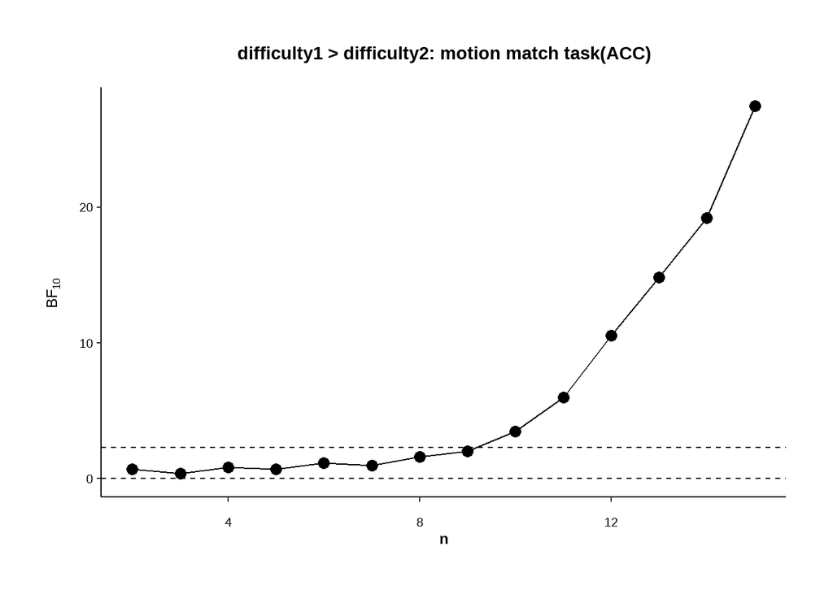

```r
plot_bfs_1vs2 <-
  plot_ttest(bfs_int_diff_mm_acc, '1 vs 2', 'difficulty1 > difficulty2: motion match task(ACC)')
plot_bfs_1vs2
```

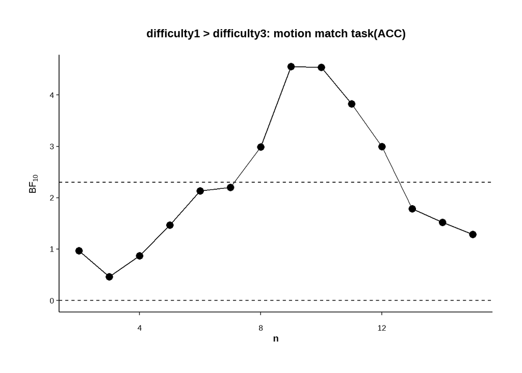

```r
plot_bfs_1vs3 <-
  plot_ttest(bfs_int_diff_mm_acc, '1 vs 3', 'difficulty1 > difficulty3: motion match task(ACC)')
plot_bfs_1vs3
```

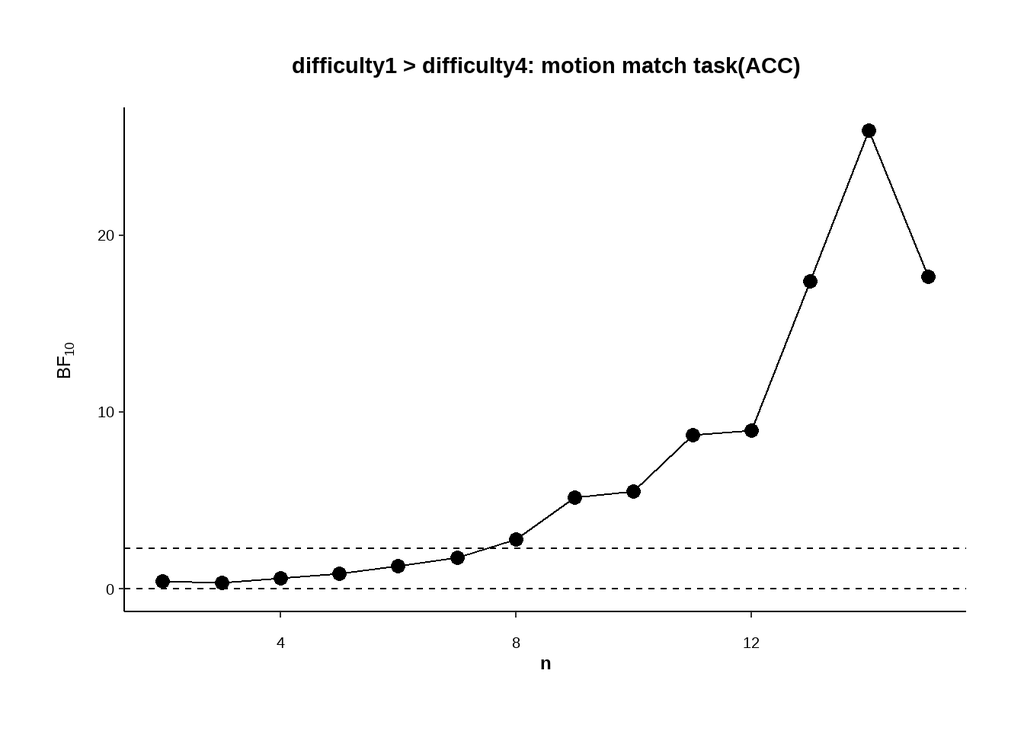

```r
plot_bfs_1vs4 <-
  plot_ttest(bfs_int_diff_mm_acc, '1 vs 4', 'difficulty1 > difficulty4: motion match task(ACC)')
plot_bfs_1vs4
```

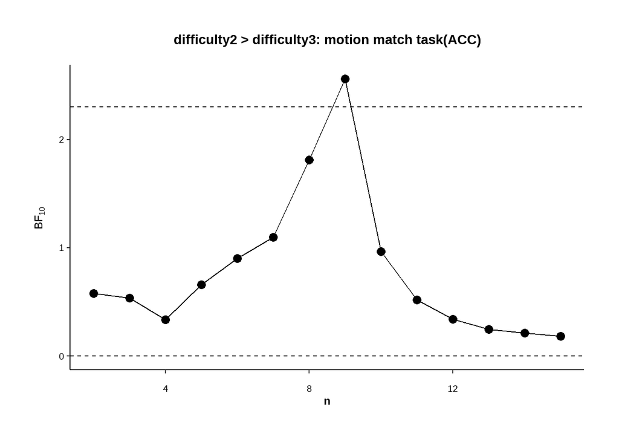

```r
plot_bfs_2vs3 <-
  plot_ttest(bfs_int_diff_mm_acc, '2 vs 3', 'difficulty2 > difficulty3: motion match task(ACC)')
plot_bfs_2vs3
```

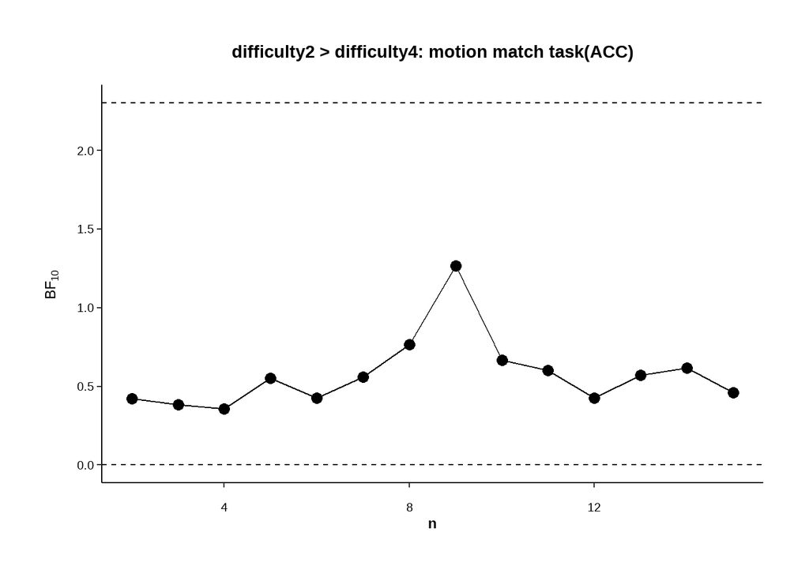

```r
plot_bfs_2vs4 <-
  plot_ttest(bfs_int_diff_mm_acc, '2 vs 4', 'difficulty2 > difficulty4: motion match task(ACC)')
plot_bfs_2vs4
```

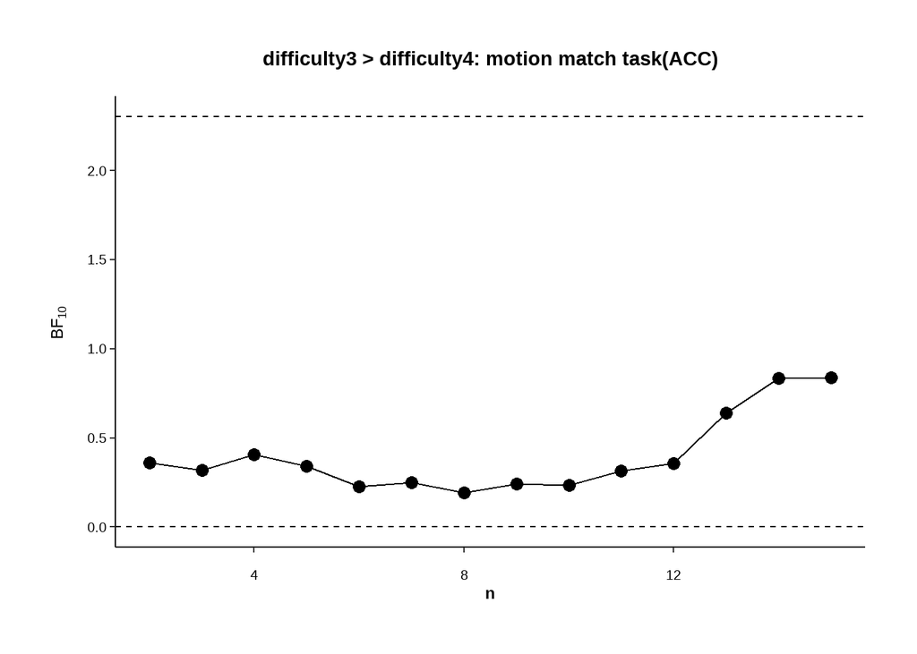

```r
plot_bfs_3vs4 <-
  plot_ttest(bfs_int_diff_mm_acc, '3 vs 4', 'difficulty3 > difficulty4: motion match task(ACC)')
plot_bfs_3vs4
```

**查看数据的变化趋势**

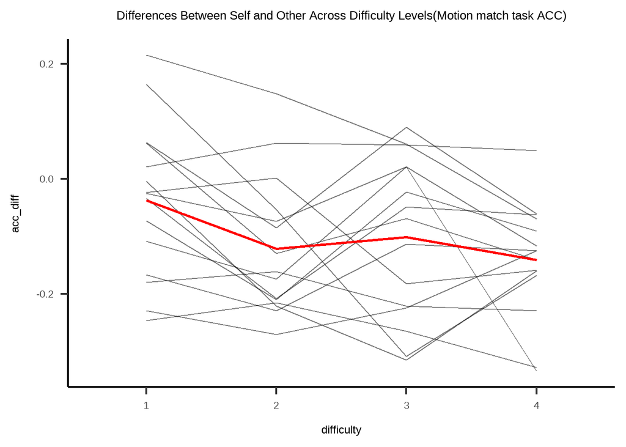

```r
# 转为长数据
df_motion_diff_match_long <- df_motion_diff_match %>%
  tidyr::pivot_longer(
    cols = starts_with(c("acc_diff_so", "rt_diff_os")),
    names_to = c(".value", "difficulty"),
    names_pattern = "^(acc_diff|rt_diff)_[^_]+_(\\d+)$",  # 简化正则表达式
    values_drop_na = TRUE
  )

ggplot(df_motion_diff_match_long, aes(x = difficulty, y = acc_diff, group = subj_idx)) +
  geom_line(alpha = 0.5) +
  stat_summary(aes(group = 1), fun = mean, geom = "line", color = "red", size = 1) + labs(title = "Differences Between Self and Other Across Difficulty Levels(Motion match task ACC)") +
  papaja::theme_apa(base_size = 18, # base_family = "Times"
                    )
```

###### 0.3.1.1.2.2 RT

```r
# 调用函数进行不同条件的两两比较
bfs_int_diff_mm_rt <- bf_pairwise_tests(df_motion_diff_match, "rt_diff_os_")

# 提取BF值到数据框
bfs_int_diff_mm_rt <- do.call(rbind, lapply(names(bfs_int_diff_mm_rt), function(iter){
  do.call(rbind, lapply(names(bfs_int_diff_mm_rt[[iter]]), function(comparison){
    data.frame(
      subj_idx = iter,
      Effect = comparison,
      BFs = bfs_int_diff_mm_rt[[iter]][[comparison]]$BF,
      Direction = bfs_int_diff_mm_rt[[iter]][[comparison]]$Direction
    )
  }))
})) %>%
  mutate(subj_idx = as.numeric(subj_idx))

bfs_int_diff_mm_rt
```

```
##    subj_idx Effect       BFs     Direction
## 1         2 1 vs 2 0.3456377  -49.64971532
## 2         2 1 vs 3 0.7541174   99.32229908
## 3         2 1 vs 4 0.3947668 -113.43620012
## 4         2 2 vs 3 0.8241997  148.97201440
## 5         2 2 vs 4 0.4480930  -63.78648480
## 6         2 3 vs 4 0.3103428 -212.75849920
## 7         3 1 vs 2 0.4037091  -10.85675466
## 8         3 1 vs 3 0.9988398  120.48056653
## 9         3 1 vs 4 0.5647702   54.25126655
## 10        3 2 vs 3 0.9309285  131.33732119
## 11        3 2 vs 4 0.5963896   65.10802121
## 12        3 3 vs 4 0.3607392  -66.22929999
## 13        4 1 vs 2 0.7631103   51.98764234
## 14        4 1 vs 3 1.5208429  138.65843215
```

[output cut: 70 more lines]

**可视化**

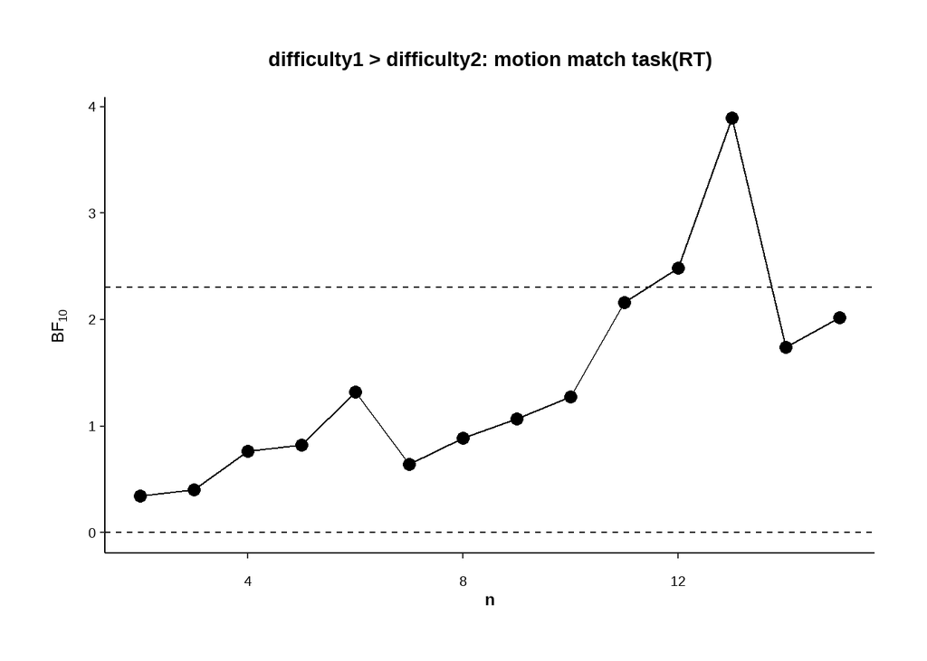

```r
plot_bfs_1vs2 <-
  plot_ttest(bfs_int_diff_mm_rt, '1 vs 2', 'difficulty1 > difficulty2: motion match task(RT)')
plot_bfs_1vs2
```

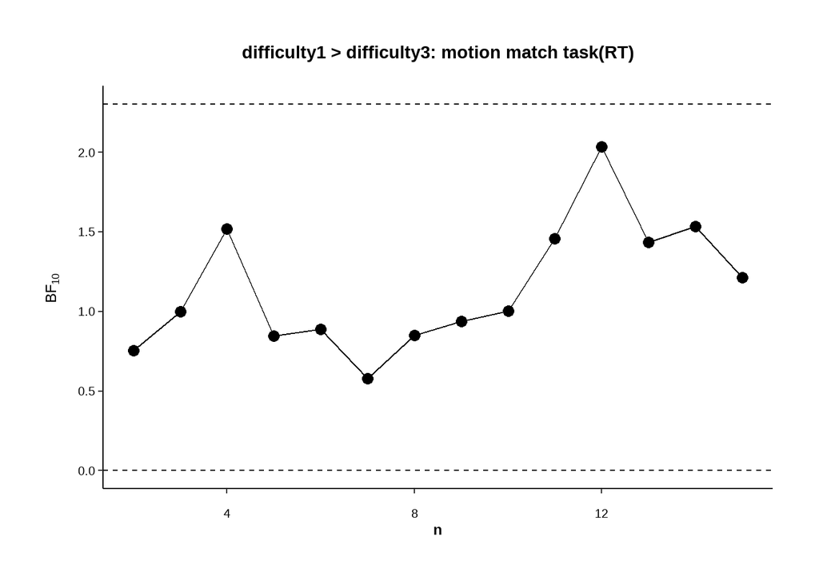

```r
plot_bfs_1vs3 <-
  plot_ttest(bfs_int_diff_mm_rt, '1 vs 3', 'difficulty1 > difficulty3: motion match task(RT)')
plot_bfs_1vs3
```

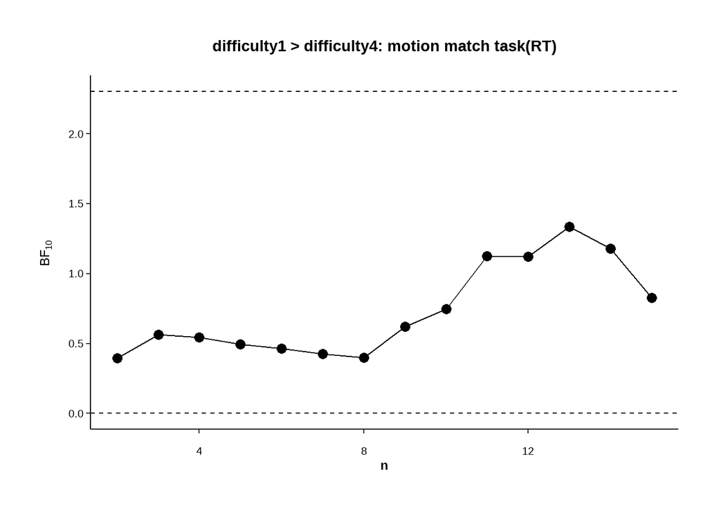

```r
plot_bfs_1vs4 <-
  plot_ttest(bfs_int_diff_mm_rt, '1 vs 4', 'difficulty1 > difficulty4: motion match task(RT)')
plot_bfs_1vs4
```

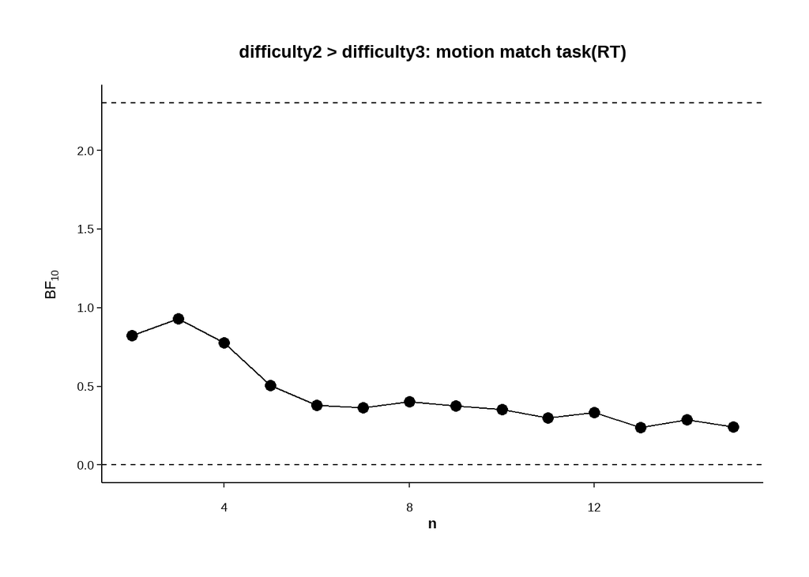

```r
plot_bfs_2vs3 <-
  plot_ttest(bfs_int_diff_mm_rt, '2 vs 3', 'difficulty2 > difficulty3: motion match task(RT)')
plot_bfs_2vs3
```

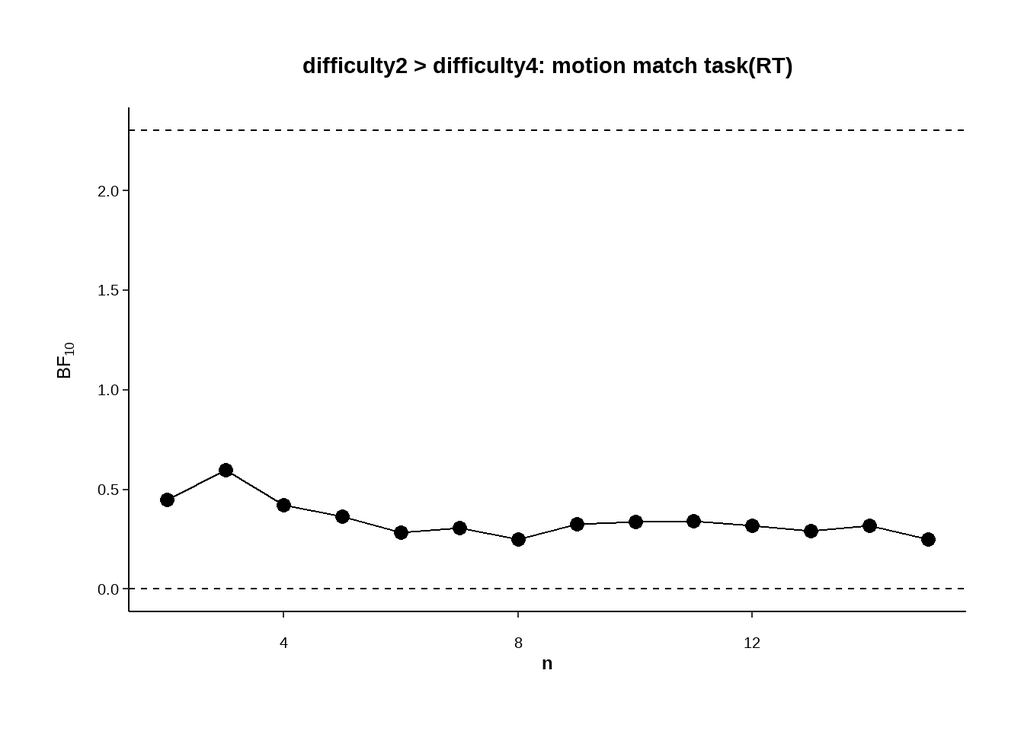

```r
plot_bfs_2vs4 <-
  plot_ttest(bfs_int_diff_mm_rt, '2 vs 4', 'difficulty2 > difficulty4: motion match task(RT)')
plot_bfs_2vs4
```

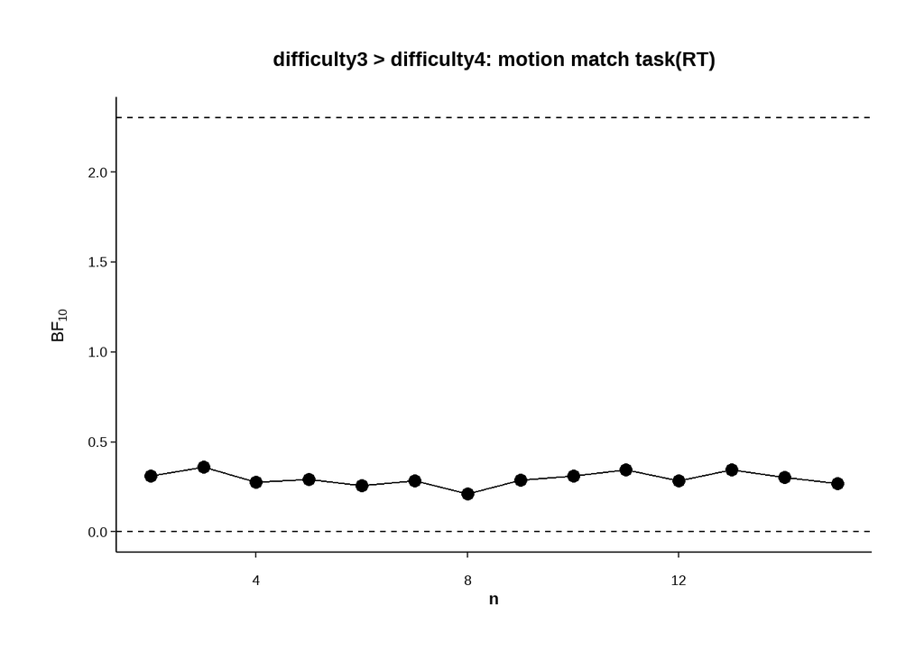

```r
plot_bfs_3vs4 <-
  plot_ttest(bfs_int_diff_mm_rt, '3 vs 4', 'difficulty3 > difficulty4: motion match task(RT)')
plot_bfs_3vs4
```

**查看数据的变化趋势**

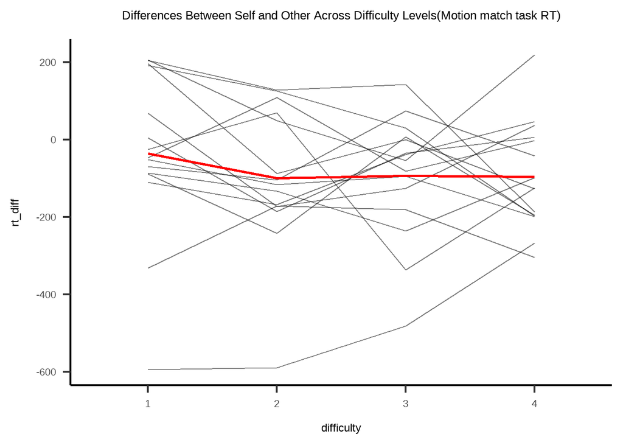

```r
ggplot(df_motion_diff_match_long, aes(x = difficulty, y = rt_diff, group = subj_idx)) +
  geom_line(alpha = 0.5) +
  stat_summary(aes(group = 1), fun = mean, geom = "line", color = "red", size = 1) + labs(title = "Differences Between Self and Other Across Difficulty Levels(Motion match task RT)") +
  papaja::theme_apa(base_size = 18,# base_family = "Times"
                    )
```

#### 0.3.1.2 辨别任务

##### 0.3.1.2.1 关联类型主效应

###### 0.3.1.2.1.1 ACC

```r
bfs_association_mr_acc <- bf_aov(df_motion_rdk, 'acc')
```

[output not shown]

[output cut: 15 more lines]

[output not shown]

[output not shown]

```r
bfs_association_mr_acc
```

```
## # A tibble: 15 × 3
##    bfs_a bfs_diff bfs_int
##    <dbl>    <dbl>   <dbl>
##  1  1          1    1
##  2  1.97    2930.   0.303
##  3  2.00    2977.   0.293
##  4  1.89    2959.   0.303
##  5  1.99    2846.   0.305
##  6  1.94    2875.   0.301
##  7  2.07    3034.   0.286
##  8  2.00    2911.   0.299
##  9  2.02    2970.   0.293
## 10  2.03    3016.   0.309
## 11  2.01    2949.   0.301
## 12  2.05    3025.   0.296
## 13  1.97    2934.   0.299
## 14  2.01    2927.   0.298
## 15  2.02    2963.   0.290
```

**可视化**

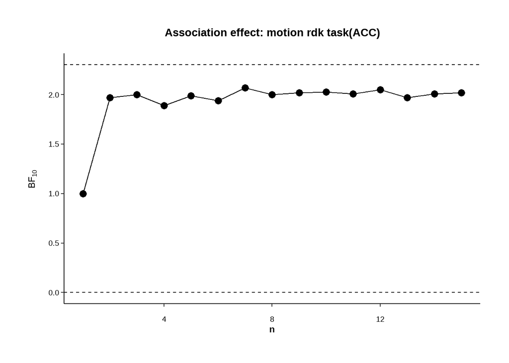

```r
plot_bfs_association <- plot_aov(bfs_association_mr_acc, 'bfs_a', 'Association effect: motion rdk task(ACC)')
plot_bfs_association
```

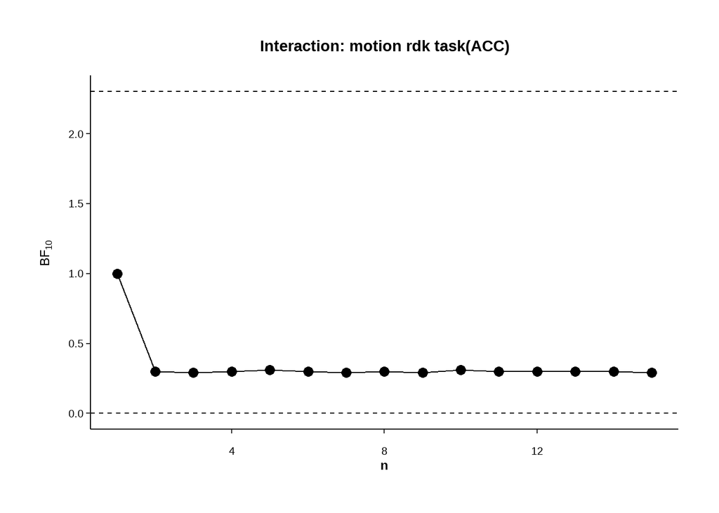

```r
plot_bfs_int <- plot_aov(bfs_association_mr_acc, 'bfs_int', 'Interaction: motion rdk task(ACC)')
plot_bfs_int
```

###### 0.3.1.2.1.2 RT

```r
bfs_association_mr_rt <- bf_aov(df_motion_rdk, 'rt')
```

[output not shown]

[output cut: 15 more lines]

[output not shown]

[output not shown]

```r
bfs_association_mr_rt
```

```
## # A tibble: 15 × 3
##    bfs_a bfs_diff bfs_int
##    <dbl>    <dbl>   <dbl>
##  1  1         1     1
##  2  1.37     28.2   0.553
##  3  1.44     31.5   0.517
##  4  1.29     30.0   0.532
##  5  1.41     28.8   0.555
##  6  1.39     28.8   0.530
##  7  1.51     31.6   0.496
##  8  1.44     30.5   0.523
##  9  1.41     29.3   0.533
## 10  1.43     30.5   0.570
## 11  1.46     30.9   0.526
## 12  1.60     33.8   0.479
## 13  1.45     32.0   0.514
## 14  1.43     29.8   0.533
## 15  1.41     30.3   0.511
```

**可视化**

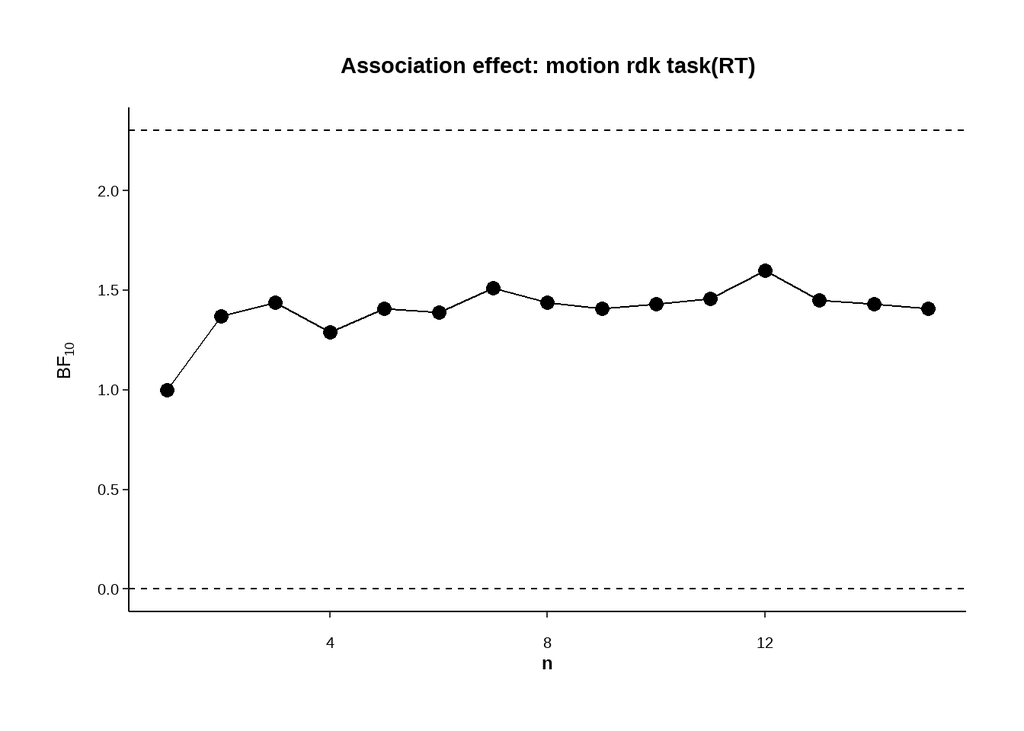

```r
plot_bfs_association <- plot_aov(bfs_association_mr_rt, 'bfs_a', 'Association effect: motion rdk task(RT)')
plot_bfs_association
```

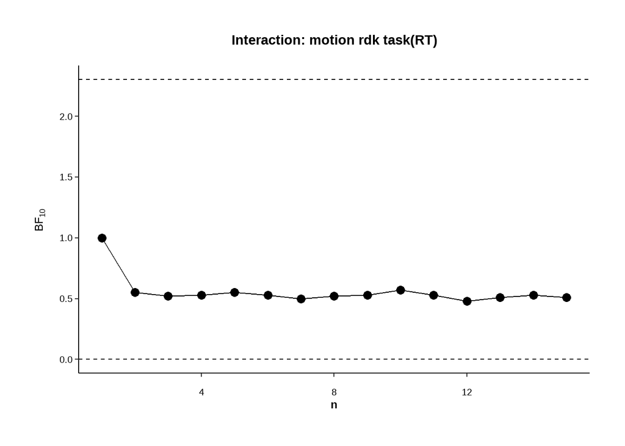

```r
plot_bfs_int <- plot_aov(bfs_association_mr_rt, 'bfs_int', 'Interaction: motion rdk task(RT)')
plot_bfs_int
```

##### 0.3.1.2.2 关联类型和难度的交互效应

###### 0.3.1.2.2.1 ACC

```r
# 调用函数进行不同条件的两两比较
bfs_int_diff_mr_acc <- bf_pairwise_tests(df_motion_diff_rdk, "acc_diff_so_")

# 提取BF值到数据框
bfs_int_diff_mr_acc <- do.call(rbind, lapply(names(bfs_int_diff_mr_acc), function(iter){
  do.call(rbind, lapply(names(bfs_int_diff_mr_acc[[iter]]), function(comparison){
    data.frame(
      subj_idx = iter,
      Effect = comparison,
      BFs = bfs_int_diff_mr_acc[[iter]][[comparison]]$BF,
      Direction = bfs_int_diff_mr_acc[[iter]][[comparison]]$Direction
    )
  }))
})) %>%
  mutate(subj_idx = as.numeric(subj_idx))

bfs_int_diff_mr_acc
```

```
##    subj_idx Effect        BFs     Direction
## 1         2 1 vs 2 0.60786007  2.083333e-02
## 2         2 1 vs 3 0.31685101 -1.250000e-01
## 3         2 1 vs 4 0.38575097 -1.250000e-01
## 4         2 2 vs 3 0.35170805 -1.458333e-01
## 5         2 2 vs 4 0.33539518 -1.458333e-01
## 6         2 3 vs 4 0.52315658  2.775558e-17
## 7         3 1 vs 2 0.37731097 -2.777778e-02
## 8         3 1 vs 3 0.24157692 -1.527778e-01
## 9         3 1 vs 4 0.27648615 -1.944444e-01
## 10        3 2 vs 3 0.27482573 -1.250000e-01
## 11        3 2 vs 4 0.25029542 -1.666667e-01
## 12        3 3 vs 4 0.39395030 -4.166667e-02
## 13        4 1 vs 2 0.38032349 -1.041667e-02
## 14        4 1 vs 3 0.19412160 -1.458333e-01
```

[output cut: 70 more lines]

**可视化**

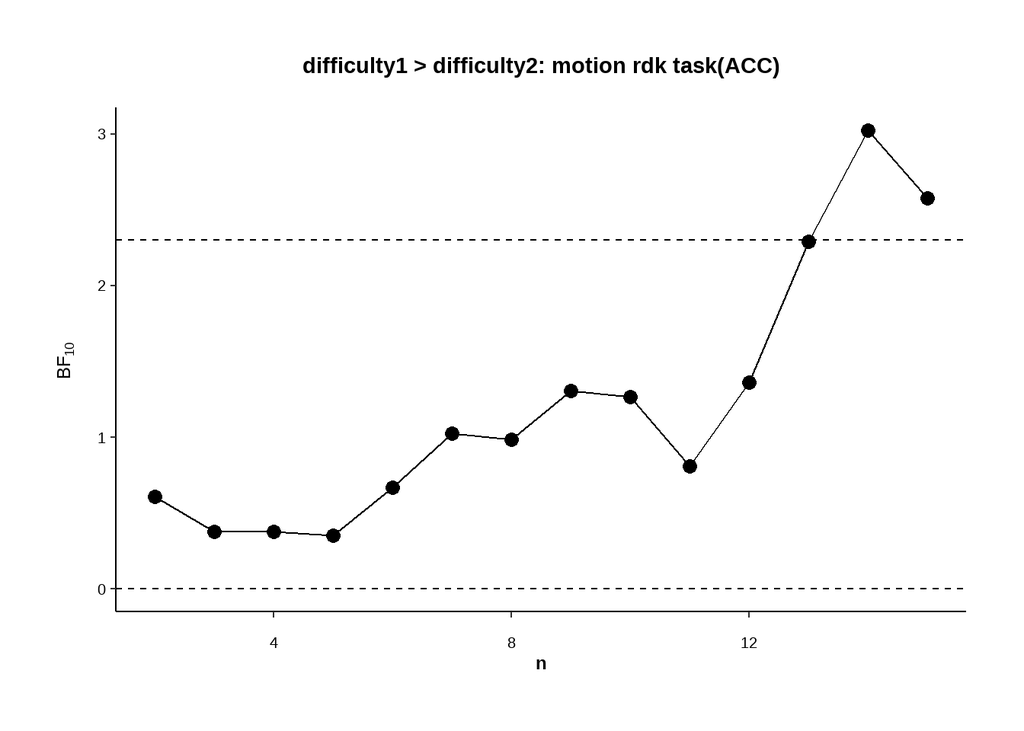

```r
plot_bfs_1vs2 <-
  plot_ttest(bfs_int_diff_mr_acc, '1 vs 2', 'difficulty1 > difficulty2: motion rdk task(ACC)')
plot_bfs_1vs2
```

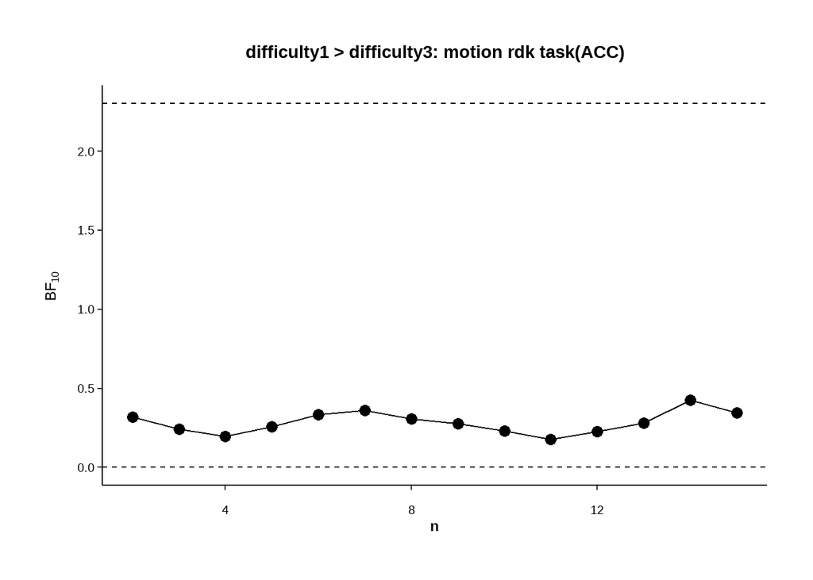

```r
plot_bfs_1vs3 <-
  plot_ttest(bfs_int_diff_mr_acc, '1 vs 3', 'difficulty1 > difficulty3: motion rdk task(ACC)')
plot_bfs_1vs3
```

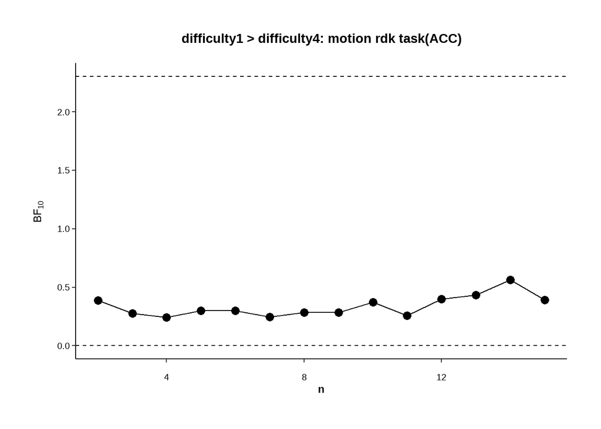

```r
plot_bfs_1vs4 <-
  plot_ttest(bfs_int_diff_mr_acc, '1 vs 4', 'difficulty1 > difficulty4: motion rdk task(ACC)')
plot_bfs_1vs4
```

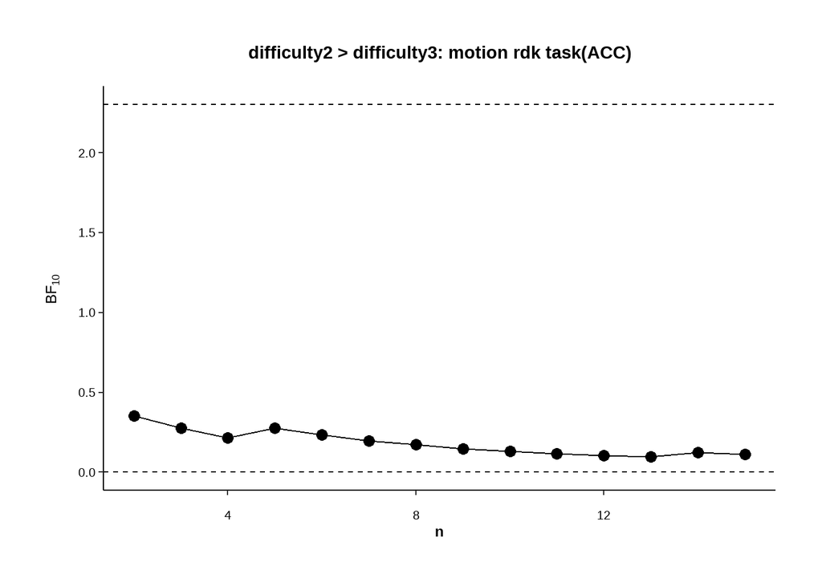

```r
plot_bfs_2vs3 <-
  plot_ttest(bfs_int_diff_mr_acc, '2 vs 3', 'difficulty2 > difficulty3: motion rdk task(ACC)')
plot_bfs_2vs3
```

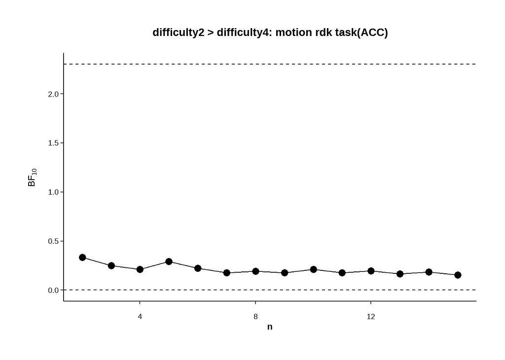

```r
plot_bfs_2vs4 <-
  plot_ttest(bfs_int_diff_mr_acc, '2 vs 4', 'difficulty2 > difficulty4: motion rdk task(ACC)')
plot_bfs_2vs4
```

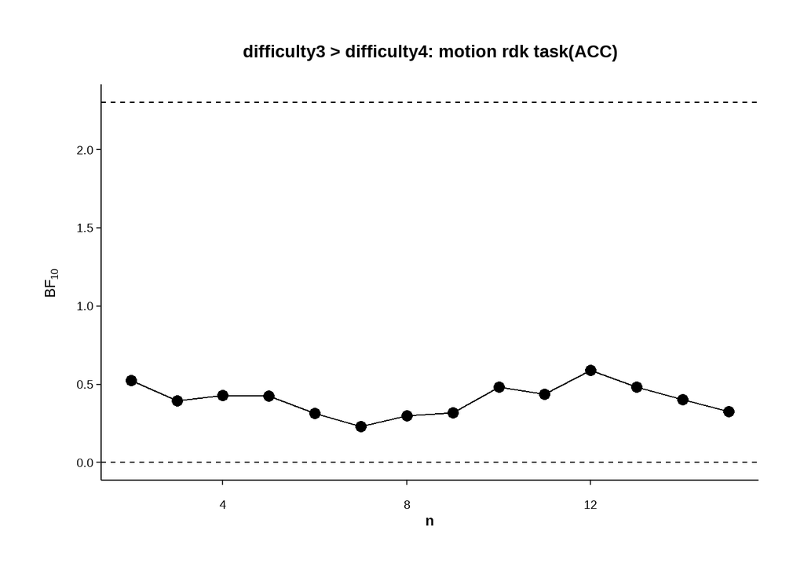

```r
plot_bfs_3vs4 <-
  plot_ttest(bfs_int_diff_mr_acc, '3 vs 4', 'difficulty3 > difficulty4: motion rdk task(ACC)')
plot_bfs_3vs4
```

**查看数据的变化趋势**

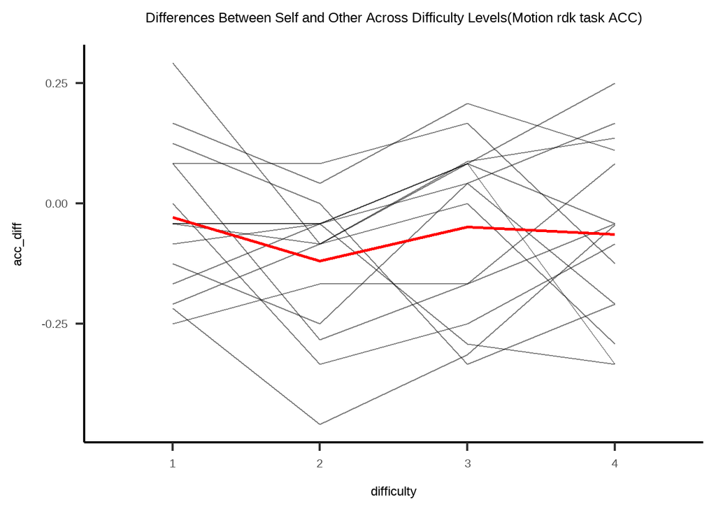

```r
# 转为长数据
df_motion_diff_rdk_long <- df_motion_diff_rdk %>%
  tidyr::pivot_longer(
    cols = starts_with(c("acc_diff_so", "rt_diff_os")),
    names_to = c(".value", "difficulty"),
    names_pattern = "^(acc_diff|rt_diff)_[^_]+_(\\d+)$",  # 简化正则表达式
    values_drop_na = TRUE
  )

ggplot(df_motion_diff_rdk_long, aes(x = difficulty, y = acc_diff, group = subj_idx)) +
  geom_line(alpha = 0.5) +
  stat_summary(aes(group = 1), fun = mean, geom = "line", color = "red", size = 1) + labs(title = "Differences Between Self and Other Across Difficulty Levels(Motion rdk task ACC)") +
  papaja::theme_apa(base_size = 18, # base_family = "Times"
                    )
```